# R Notebook

```r
Chi_Square_Normal_Test <- function(x, n) {
   break_p <- vector("double", length = n + 1)
   x_mean <- mean(x)
   x_stdev <- sqrt(var(x))
   break_p[1] <- min(x) - 1
   size <- length(x)
   for(j in 2:n) {
      break_p[j] <- qnorm((j-1)/n, mean = x_mean,
      sd = x_stdev, lower.tail = TRUE, log.p = FALSE)
      }
   break_p[n+1] <- max(x) + 1
   p_x <- hist(x, breaks = break_p, plot = FALSE)
   x_Counts <- p_x$counts
   Norm_counts <- vector("double", length = n)
   for(j in 1:n) {
      Norm_counts[j] <- size * 1/n
      }
   p_SE <- hist(x, breaks = break_p, main="Histogram of
   Standardized Errors")
   normal_fit <- chisq.test(x_Counts, p = Norm_counts,
   rescale.p = TRUE)
   Chitest_value <- pchisq(normal_fit$statistic, df = n - 3,
   lower.tail=FALSE)
   return(Chitest_value)
}
```

```r
standarized_errors_MR <- function(y, x) {
   n <- length(y)
   k <- ncol(x)
   x1 <- vector("double", length = n)
   for(j in 1:n) {
      x1[j] <- 1
      }
   Matrix_X <- cbind(x1, x)
   Matrix_Y <- cbind(y)
   Matrix_H <- Matrix_X%*%solve(t(Matrix_X)%*%Matrix_X)%*%t(Matrix_X)
   Matrix_YP <- Matrix_H%*%Matrix_Y
   y_p <- Matrix_YP[,1]
   h <- vector("double", length = n)
   D <- vector("double", length = n)
   Error <- vector("double", length = n)
   Standard_E <- vector("double", length = n)
   se <- sqrt(sum((y - y_p)^2)/(n - k - 1))
   for(i in 1:n) {
      h[i] <- Matrix_H[i,i]
      Error[i] <- y[i] - y_p[i]
      Standard_E[i] <- Error[i] / (se * sqrt(1 - h[i]))
      D[i] <- (y[i] - y_p[i])^2 * h[i] / ((k - 1) * se^2 * (1 - h[i])^2)
      }
    SEhD <- cbind(Standard_E,h,D)
   return(SEhD)}
```

```r
Run_Test <- function(x) {
    size <- length(x)
  Run_Count <- vector("double", length = size)
  x_median <- median(x)
    x_cat <- x > x_median
    print(x_cat)
    Run_Count[1] <- 1
    for(j in 2:n) {
    if (x_cat[j] == x_cat[j-1]) {
      Run_Count[j] <- Run_Count[j-1]
  } else {
      Run_Count[j] <- Run_Count[j-1] + 1
          }
    }
    n1 <- sum(x_cat == 'TRUE')
    n2 <- sum(x_cat == 'FALSE')
    Run_Mean <- 2*n1*n2/(n1+n2) + 1
    Run_S <- sqrt(2*n1*n2*(2*n1*n2-n1-n2)/(n1+n2)^2/(n1+n2-1))
    Run_Z = (Run_Count[size] - Run_Mean) / Run_S
    if (Run_Z < 0) {
      Run_Pvalue <- pnorm(Run_Count[size], mean=Run_Mean, sd=Run_S, lower.tail=TRUE)*2
  } else {
      Run_Pvalue <- pnorm(Run_Count[size], mean=Run_Mean, sd=Run_S, lower.tail=FALSE)*2
          }
    Run_Return_V <- vector("double", length = 7)
    Run_Return_V[1] <- n1
    Run_Return_V[2] <- n2
    Run_Return_V[3] <- Run_Count[size]
    Run_Return_V[4] <- Run_Mean
    Run_Return_V[5] <- Run_S
    Run_Return_V[6] <- Run_Z
    Run_Return_V[7] <- Run_Pvalue
    return(Run_Return_V)
}
```

```r
Hetero_plot <- function(y,x,l)
{
  n <- length(y)
  linearModelVar <- lm(y ~ x)
  a <- coef(linearModelVar)[1]
  b = vector("numeric",l)
  for(i in 1:l)
  {
    b[i] <- coef(linearModelVar)[i+1]
  }
  Price_p <- vector("double", length = n)
  for(i in 1:n) {
    temp = a
    for(j in 1:l)
      temp = temp + b[j]*x[i,j]
    Price_p[i] <- temp
  }
  Standard_E <- standarized_errors_MR(y,x)[,1]
  plot(x = Price_p,y = Standard_E,  xlab = "Predicted Price",  ylab = "Standardized Error",  xlim = c(min(Price_p)-0.1,max(Price_p)+0.1),  ylim = c(-3,3), main = "y vs Error")

}
```

# Exercise 17.03

```r
read1703 <- read.csv("D:\\Xr17-03.csv")
data1703 <- data.frame(read1703)
```

## 1. Plot the scatter diagram

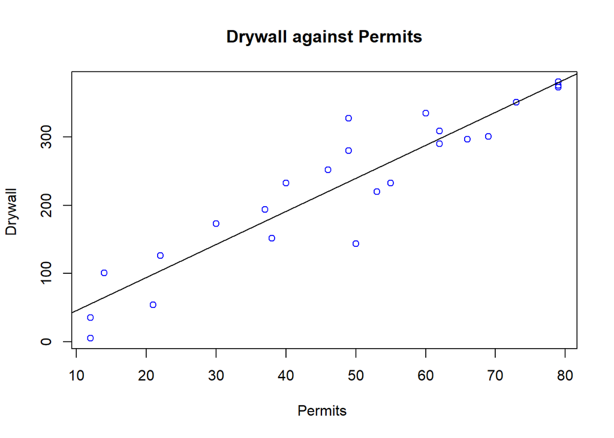

```r
Drywall <- read1703$Drywall
Permits <- read1703$Permits
n <- length(Drywall)
plot(Permits, Drywall, col = "blue", main = "Drywall against Permits", xlab = "Permits ", ylab = "Drywall ")
abline(lm(Drywall ~ Permits))
```

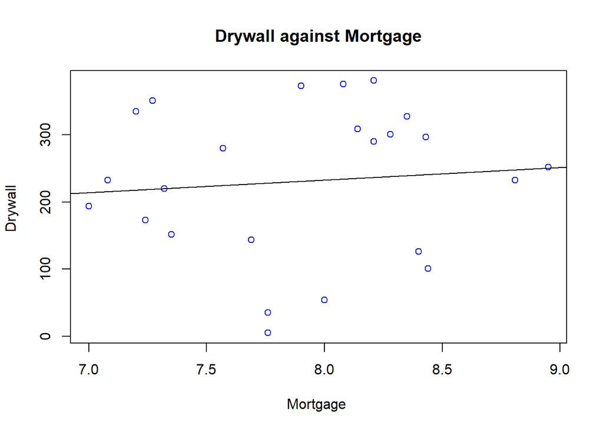

```r
Drywall <- read1703$Drywall
Mortgage <- read1703$Mortgage
n <- length(Drywall)
plot(Mortgage, Drywall, col = "blue", main = "Drywall against Mortgage", xlab = "Mortgage ", ylab = "Drywall ")
abline(lm(Drywall ~ Mortgage))
```

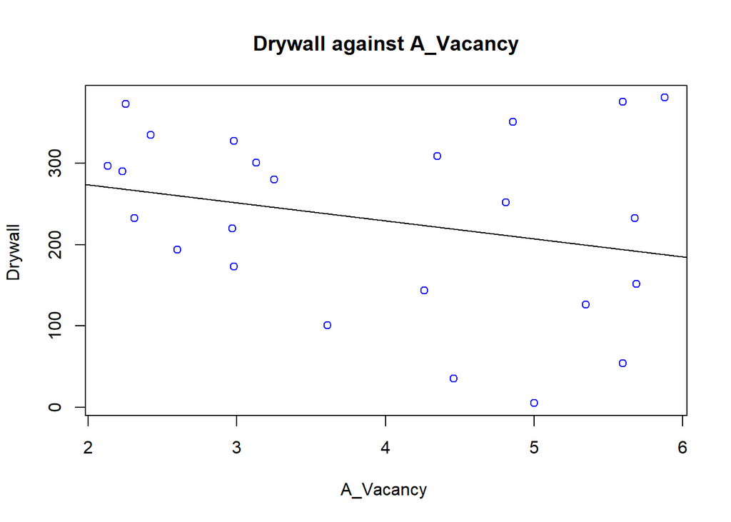

```r
Drywall <- read1703$Drywall
A_Vacancy <- read1703$Vacancy1
n <- length(Drywall)
plot(A_Vacancy, Drywall, col = "blue", main = "Drywall against A_Vacancy", xlab = "A_Vacancy ", ylab = "Drywall ")
abline(lm(Drywall ~ A_Vacancy))
```

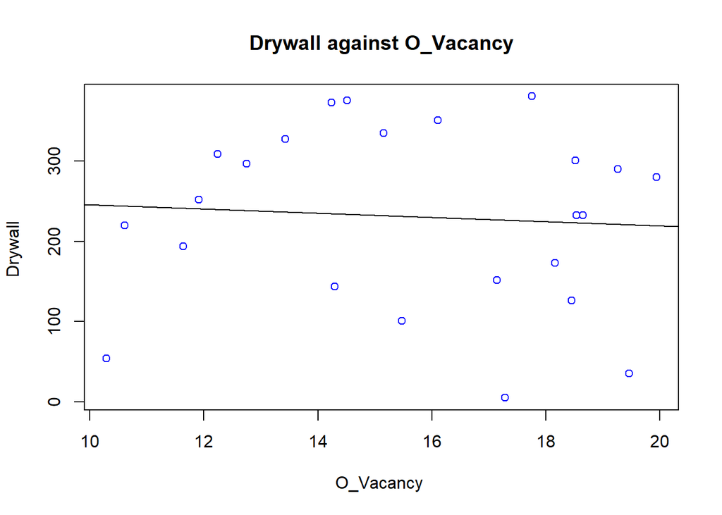

```r
Drywall <- read1703$Drywall
O_Vacancy <- read1703$Vacancy2
n <- length(Drywall)
plot(O_Vacancy, Drywall, col = "blue", main = "Drywall against O_Vacancy", xlab = "O_Vacancy ", ylab = "Drywall ")
abline(lm(Drywall ~ O_Vacancy))
```

## 2. Propose a statistical model

Suppose that demand of drywall is related to the number of permits (x1), the Five-year mortgage rates (x2), the Vacancy rate in apartments (x3) and the Vacancy rate in office buildings(x4) and the error$\epsilon$ by the following regression model:
$$y = \beta_0 + \beta_1x_1 + \beta_2x_2 + \beta_3x_3 + \beta_4x_4 + \epsilon$$
where y = demand of drywall), x1= the number of permits, x2= the Five-year mortgage rates, x3= the Vacancy rate in apartments, x4= the Vacancy rate in office buildings. ε = error variable.

## 3. Fit the model

```r
n <- length(Drywall)
Data.read1703 <- cbind(Permits, Mortgage, A_Vacancy, O_Vacancy)
linearModelVar <- lm(Drywall ~ Data.read1703)
cat("# # # # The regression model # # # ","\n")
```

```
## # # # # The regression model # # #
```

```r
print(summary(linearModelVar))
```

```
##
## Call:
## lm(formula = Drywall ~ Data.read1703)
##
## Residuals:
##     Min      1Q  Median      3Q     Max
## -86.822 -25.351   9.409  22.602  78.391
##
## Coefficients:
##                        Estimate Std. Error t value Pr(>|t|)
## (Intercept)            -111.828    134.343  -0.832    0.416
## Data.read1703Permits      4.763      0.395  12.057 2.39e-10 ***
## Data.read1703Mortgage    16.988     15.159   1.121    0.276
## Data.read1703A_Vacancy  -10.528      6.394  -1.646    0.116
## Data.read1703O_Vacancy    1.308      2.791   0.469    0.645
## ---
## Signif. codes:  0 '***' 0.001 '**' 0.01 '*' 0.05 '.' 0.1 ' ' 1
##
## Residual standard error: 40.13 on 19 degrees of freedom
## Multiple R-squared:  0.8935, Adjusted R-squared:  0.8711
## F-statistic: 39.86 on 4 and 19 DF,  p-value: 5.448e-09
```

```r
ANOVA_T_lm <- anova(linearModelVar)
cat("# # # # The ANOVA Table # # # ","\n")
```

```
## # # # # The ANOVA Table # # #
```

```r
print(ANOVA_T_lm)
```

```
## Analysis of Variance Table
##
## Response: Drywall
##               Df Sum Sq Mean Sq F value    Pr(>F)
## Data.read1703  4 256793   64198   39.86 5.448e-09 ***
## Residuals     19  30602    1611
## ---
## Signif. codes:  0 '***' 0.001 '**' 0.01 '*' 0.05 '.' 0.1 ' ' 1
```

The regression line is y_head = −111.828+4.763$x_1$+16.988$x_2$−10.528$x_3$+1.308$x_4$

## 4. Residual analysis

Standardized Residuals

```r
SE <- standarized_errors_MR(Drywall, Data.read1703)[,1]
h <- standarized_errors_MR(Drywall, Data.read1703)[,2]
D <- standarized_errors_MR(Drywall, Data.read1703)[,3]
cat("# # # # The Standardized Errors # # # ","\n")
```

```
## # # # # The Standardized Errors # # #
```

```r
print(SE)
```

```
##  [1]  2.0728732  0.4068178 -0.5680216 -2.2314624  0.6842512 -0.7853130
##  [7]  0.6307879 -1.3016241 -0.7506256  0.8205666  0.4694780  0.7367955
## [13] -0.1240052  0.6001194 -0.0538226 -0.5823194 -0.9736954 -1.1626043
## [19]  1.2203271  1.0318563  0.5737238 -1.2003317  0.4538470  0.1343434
```

```r
cat("# # # # hi # # # ","\n")
```

```
## # # # # hi # # #
```

```r
print(h)
```

```
##  [1] 0.11203574 0.23751656 0.18334555 0.06007856 0.30926433 0.23420204
##  [7] 0.20800977 0.16410178 0.33270833 0.29038919 0.30051393 0.19321400
## [13] 0.16439163 0.18727878 0.25004708 0.21856041 0.21275486 0.18497074
## [19] 0.17850231 0.15928891 0.20473899 0.20323454 0.12698333 0.28386865
```

```r
cat("# # # # Di # # # ","\n")
```

```
## # # # # Di # # #
```

```r
print(D)
```

```
##  [1] 0.1807112992 0.0171847091 0.0241457362 0.1060927932 0.0698759672
##  [6] 0.0628696063 0.0348344820 0.1108689097 0.0936425893 0.0918473436
## [11] 0.0315642026 0.0433364040 0.0010084054 0.0276631124 0.0003219555
## [16] 0.0316138525 0.0854071930 0.1022521510 0.1078620767 0.0672443717
## [21] 0.0282471975 0.1225034472 0.0099866990 0.0023847123
```

Non-normality

$H_0$ :Errors are normally distributed

$H_1$:Errors are not normally distributed

```r
Chi_normal_value <- Chi_Square_Normal_Test(SE, 4)
```

[figure not shown]

```r
print(Chi_normal_value)
```

```
## X-squared
## 0.3173105
```

since p_value = 0.3173105 > 0.05. We can assume that errors are normally distributed.

Heteroscedasticity and homoscedasticity

$H_0$:Homoscedasticity

$H_1$:Heteroscedasticity

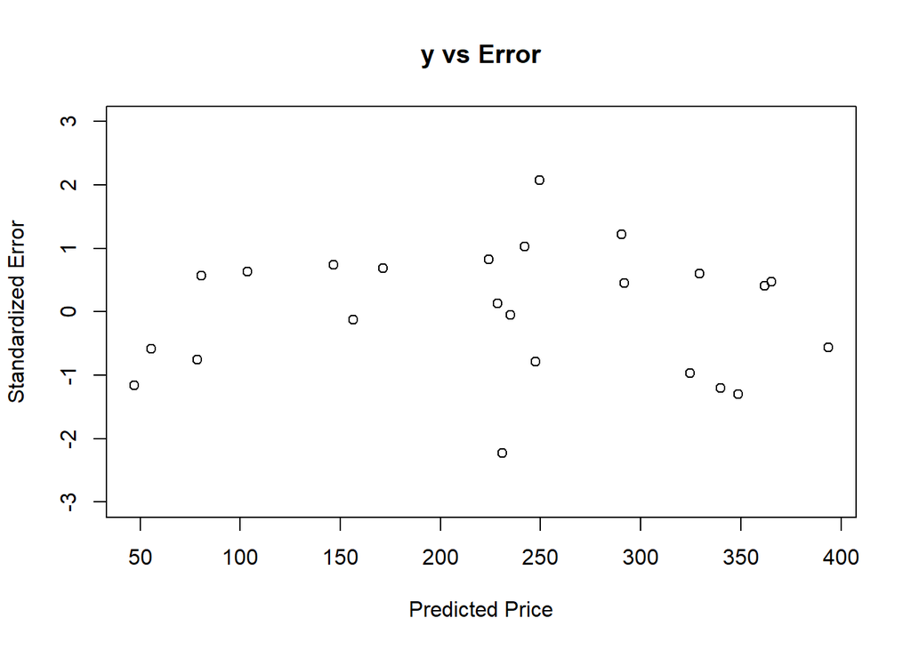

```r
Hetero_plot(Drywall,Data.read1703,4)
```

It appears thatthe variation is constant and the mean is around 0.

Non-independence of the Error Variable

```r
Run_Test_Result <- Run_Test(SE)
```

```
##  [1]  TRUE  TRUE FALSE FALSE  TRUE FALSE  TRUE FALSE FALSE  TRUE  TRUE
## [12]  TRUE FALSE  TRUE FALSE FALSE FALSE FALSE  TRUE  TRUE  TRUE FALSE
## [23]  TRUE FALSE
```

```r
cat("     ","\n")
```

```r
cat("# # # # The Run Test # # # ","\n")
```

```
## # # # # The Run Test # # #
```

```r
print(Run_Test_Result)
```

```
## [1] 12.0000000 12.0000000 14.0000000 13.0000000  2.3956482  0.4174236
## [7]  0.6763686
```

Because 17 > R = 14 > 9, do not rejected H0. We can assume that samples are randomly selected.

Outliers and onfluential observations

```r
cat("# # # # Outliers # # # ","\n")
```

```
## # # # # Outliers # # #
```

```r
as.data.frame(data1703[abs(SE) > 2,])
```

|  | Drywall | Permits | Mortgage | Vacancy1 | Vacancy2 |
| --- | --- | --- | --- | --- | --- |
| 1 | 328 | 49 | 8.35 | 2.98 | 13.43 |
| 4 | 144 | 50 | 7.69 | 4.26 | 14.30 |

There are 2 possible outliers, which are (328, 49, 8.35, 2.98, 13.43) and (144, 50, 7.69, 4.26, 14.30), since their standardized residuals are bigger than 2 or less than -2.

Influential observation

```r
n <- length(Drywall)
Data.Inn_Profit <- cbind(Permits, Mortgage, A_Vacancy, O_Vacancy)
h <- standarized_errors_MR(Drywall, Data.Inn_Profit)[,2]
cat("     ","\n")
```

```r
cat("# # # # hii # # # ","\n")
```

```
## # # # # hii # # #
```

```r
print(h)
```

```
##  [1] 0.11203574 0.23751656 0.18334555 0.06007856 0.30926433 0.23420204
##  [7] 0.20800977 0.16410178 0.33270833 0.29038919 0.30051393 0.19321400
## [13] 0.16439163 0.18727878 0.25004708 0.21856041 0.21275486 0.18497074
## [19] 0.17850231 0.15928891 0.20473899 0.20323454 0.12698333 0.28386865
```

```r
n <- length(h)
cat("     ","\n")
```

```r
cat("# # # # Influential Observations by h # # # ","\n")
```

```
## # # # # Influential Observations by h # # #
```

```r
k <- dim(Data.Inn_Profit)[2]
Inf_Obs <- h > 3*(k+1)/n
print(Inf_Obs)
```

```
##  [1] FALSE FALSE FALSE FALSE FALSE FALSE FALSE FALSE FALSE FALSE FALSE
## [12] FALSE FALSE FALSE FALSE FALSE FALSE FALSE FALSE FALSE FALSE FALSE
## [23] FALSE FALSE
```

```r
D <- standarized_errors_MR(Drywall, Data.Inn_Profit)[,3]
cat(" ","\n")
```

```r
cat("# # # # Cook's Distance # # # ","\n")
```

```
## # # # # Cook's Distance # # #
```

```r
print(D)
```

```
##  [1] 0.1807112992 0.0171847091 0.0241457362 0.1060927932 0.0698759672
##  [6] 0.0628696063 0.0348344820 0.1108689097 0.0936425893 0.0918473436
## [11] 0.0315642026 0.0433364040 0.0010084054 0.0276631124 0.0003219555
## [16] 0.0316138525 0.0854071930 0.1022521510 0.1078620767 0.0672443717
## [21] 0.0282471975 0.1225034472 0.0099866990 0.0023847123
```

```r
cat("     ","\n")
```

```r
cat("# # # # Influential Observations by Cook's Distance # # # ","\n")
```

```
## # # # # Influential Observations by Cook's Distance # # #
```

```r
Inf_Obs <- D > 1
print(Inf_Obs)
```

```
##  [1] FALSE FALSE FALSE FALSE FALSE FALSE FALSE FALSE FALSE FALSE FALSE
## [12] FALSE FALSE FALSE FALSE FALSE FALSE FALSE FALSE FALSE FALSE FALSE
## [23] FALSE FALSE
```

There is no influential observation according to both Leverage and Cook’s distance.